## Les packages à utiliser

```r
library(tidyverse)  # Modern data science workflow
library(sf)
library(sp)
library(spdep)
library(rgdal)
library(rgeos)
library(tmap)
library(tmaptools)
library(spgwr)
library(grid)
library(gridExtra)
```

## les fichiers utilisés

- Inspirés de [Guy Lansley & James Cheshire (2016)](https://data.cdrc.ac.uk/tutorial/an-introduction-to-spatial-data-analysis-and-visualisation-in-r).

## Données non spatiales

Les données sont accessibles dans le fichier practicaldata.csv. Prendre garde à la définition des répertoires. On nomme le dataframe Census.data.

```r
Census.Data <-read.csv("practicaldata.csv")
```

Pour une vue rapide des données

```r
glimpse(Census.Data)
```

```
## Rows: 749
## Columns: 5
## $ OA            <chr> "E00004120", "E00004121", "E00004122", "E00004123", "E00…
## $ White_British <dbl> 42.35669, 47.20000, 40.67797, 49.66216, 51.13636, 41.417…
## $ Low_Occupancy <dbl> 6.2937063, 5.9322034, 2.9126214, 0.9259259, 2.0000000, 3…
## $ Unemployed    <dbl> 1.8939394, 2.6881720, 1.2121212, 2.8037383, 3.8167939, 3…
## $ Qualification <dbl> 73.62637, 69.90291, 67.58242, 60.77586, 65.98639, 74.206…
```

## Données spatiales

les données ont pour nom Camden_oa11 et on va utiliser `readOGR`qui n’est utilisable que si la géométrie des données est clairement définie, ce qui n’est souvent le cas que dans des applications pédagogiques. L’objet spatial qui en résulte ets appelé Output.Areas

```r
Output.Areas <- readOGR(".", "Camden_oa11")
# Sortie très longue donc l'exécuter si nécessaire directement dans la console
glimpse(Output.Areas)
```

## Utilisation du package **sf**

Pour lire le même fichier spatial nommé Output.Areas2

```r
Output.Areas2 <- read_sf("Camden_oa11.shp")
```

```r
glimpse(Output.Areas2)
```

```
## Rows: 749
## Columns: 2
## $ OA11CD   <chr> "E00004527", "E00004525", "E00004522", "E00004287", "E0000420…
## $ geometry <POLYGON [m]> POLYGON ((530648.4 181230.2..., POLYGON ((530511.3 18…
```

## Fusion des données spatiales et non spatiales

```r
OA.Census <- merge(Output.Areas, Census.Data, by.x="OA11CD", by.y="OA")
```

Transformation en un objet `sf`

```r
OA.Census_sf <- st_as_sf(OA.Census)
```

## Distribution Spatiale

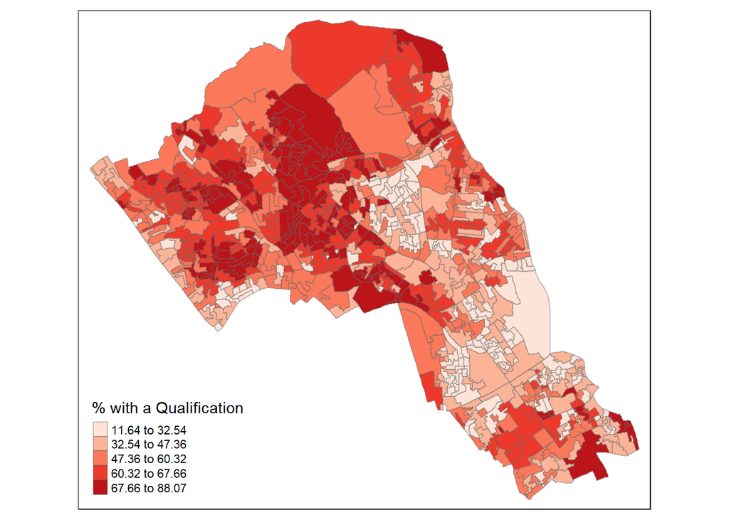

```r
tm_shape(OA.Census_sf) +
  tm_fill("Qualification",
          palette = "Reds",
          style = "quantile",
          title = "% with a Qualification") +
  tm_borders(alpha=.4)
```

## Structure de voisinage

### Contiguïté queen

A partir d’un objet `sp`

```r
neighbours <- poly2nb(OA.Census)
neighbours
```

```
## Neighbour list object:
## Number of regions: 749
## Number of nonzero links: 4342
## Percentage nonzero weights: 0.7739737
## Average number of links: 5.797063
```

A partir d’un objet `sf`

```r
neighbours_sf <- poly2nb(OA.Census_sf)
neighbours_sf
```

```
## Neighbour list object:
## Number of regions: 749
## Number of nonzero links: 4342
## Percentage nonzero weights: 0.7739737
## Average number of links: 5.797063
```

### Graphe de connectivité queen

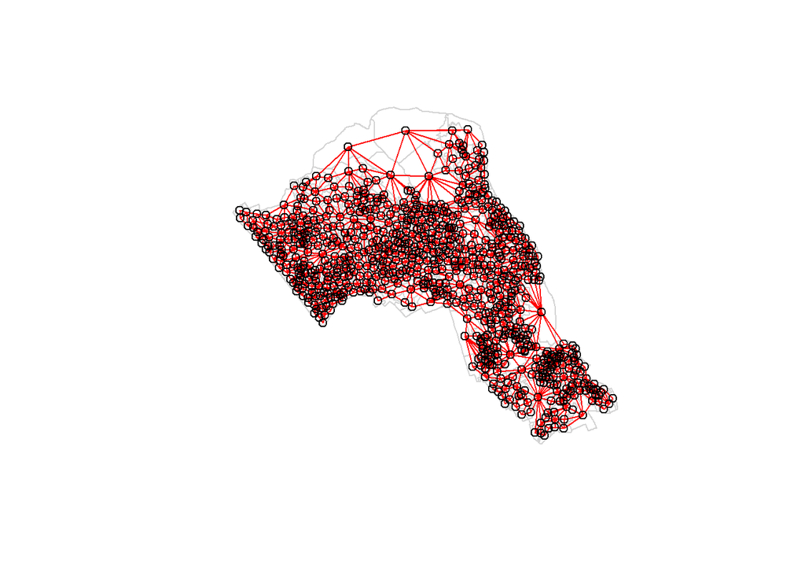

```r
plot(OA.Census, border = 'lightgrey')
plot(neighbours, coordinates(OA.Census), add=TRUE, col='red')
```

### Contiguïté rook

```r
neighbours2 <- poly2nb(OA.Census, queen = FALSE)
neighbours2
```

```
## Neighbour list object:
## Number of regions: 749
## Number of nonzero links: 4176
## Percentage nonzero weights: 0.7443837
## Average number of links: 5.575434
```

### Connectivité rook

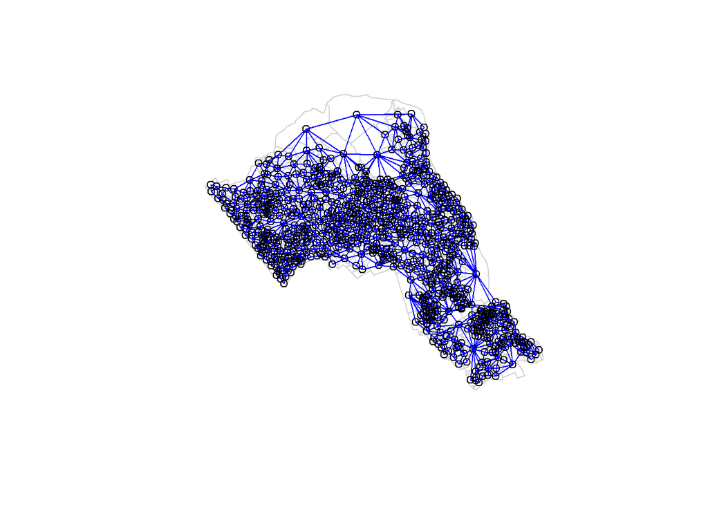

```r
plot(OA.Census, border = 'lightgrey')
plot(neighbours2, coordinates(OA.Census), add=TRUE, col='blue')
```

### Plot queen vs rook

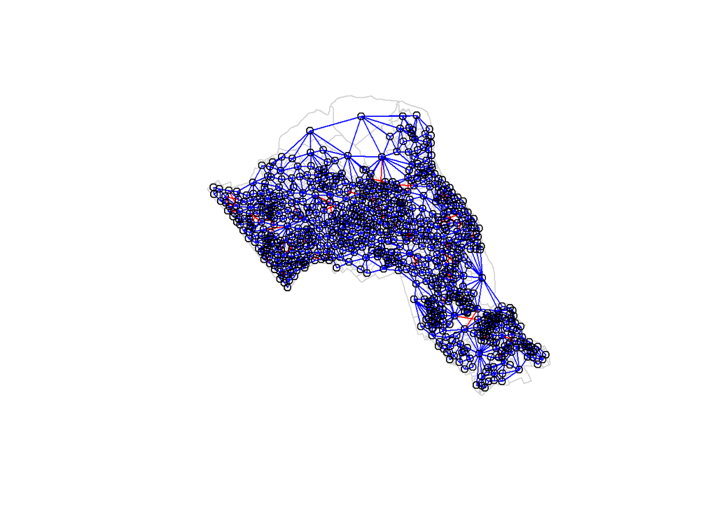

```r
plot(OA.Census, border = 'lightgrey')
plot(neighbours, coordinates(OA.Census), add=TRUE, col='red')
plot(neighbours2, coordinates(OA.Census), add=TRUE, col='blue')
```

## Autocorrélation Spatiale Globale

### Matrice de pondération spatiale

```r
listw <- nb2listw(neighbours2)
listw
```

```
## Characteristics of weights list object:
## Neighbour list object:
## Number of regions: 749
## Number of nonzero links: 4176
## Percentage nonzero weights: 0.7443837
## Average number of links: 5.575434
##
## Weights style: W
## Weights constants summary:
##     n     nn  S0       S1       S2
## W 749 561001 749 285.3793 3113.982
```

### Test de Moran Global

```r
globalMoran <- moran.test(OA.Census$Qualification, listw)
globalMoran
```

```
##
##  Moran I test under randomisation
##
## data:  OA.Census$Qualification
## weights: listw
##
## Moran I statistic standard deviate = 24.292, p-value < 2.2e-16
## alternative hypothesis: greater
## sample estimates:
## Moran I statistic       Expectation          Variance
##      0.5448699398     -0.0013368984      0.0005055733
```

```r
globalMoran[["estimate"]][["Moran I statistic"]]
```

```
## [1] 0.5448699
```

```r
globalMoran[["p.value"]]
```

```
## [1] 1.187938e-130
```

The Moran I statistic is 0.54, we can, therefore, determine that there our qualification variable is positively autocorrelated in Camden. In other words, the data does spatially cluster. We can also consider the p-value as a measure of the statistical significance of the model.

### Autocorrélation spatiale Locale

#### Moran scatterplot

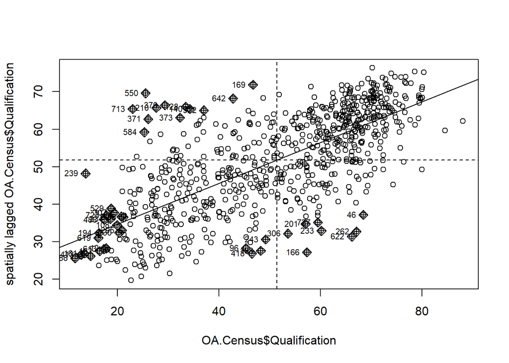

```r
moran <- moran.plot(OA.Census$Qualification, listw = nb2listw(neighbours2, style = "W"))
```

#### Calcul de la statistique de Moran locale

```r
local <- localmoran(x = OA.Census$Qualification, listw = nb2listw(neighbours2, style = "W"))
```

- Ii: local moran statistic
- E.Ii: expectation of local moran statistic
- Var.Ii: variance of local moran statistic
- Z.Ii: standard deviate of local moran statistic
- Pr(): p-value of local moran statistic

#### Représentation graphique

```r
# binds results to our polygon shapefile
moran.map <- cbind(OA.Census, local)
```

```
## Variable(s) "Ii" contains positive and negative values, so midpoint is set to 0. Set midpoint = NA to show the full spectrum of the color palette.
```

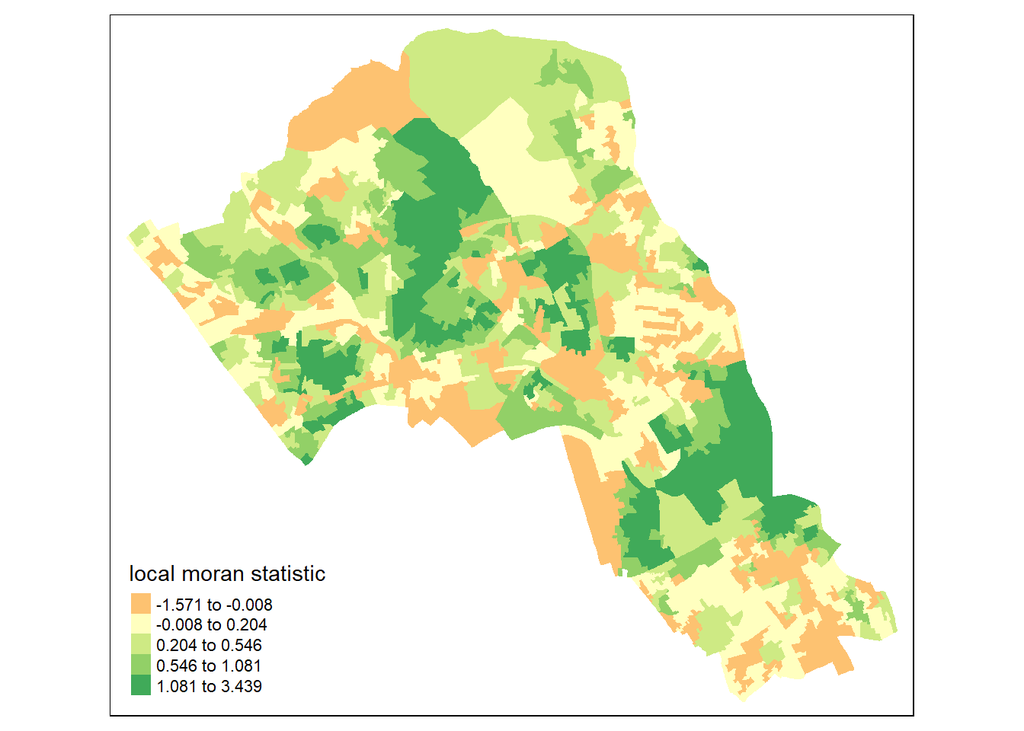

```r
tm_shape(moran.map) +
  tm_fill(col = "Ii",
          style = "quantile",
          title = "local moran statistic")
```

#### Plot LISA clusters

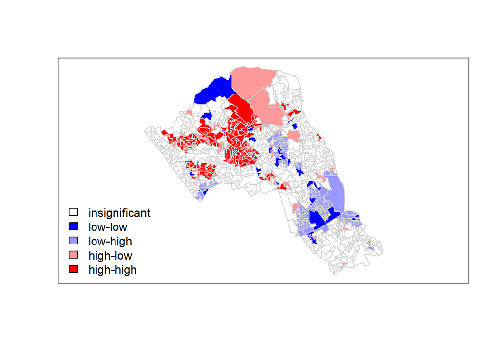

```r
quadrant <- vector(mode="numeric",length=nrow(local))

# centers the variable of interest around its mean
m.qualification <- OA.Census$Qualification - mean(OA.Census$Qualification)

# centers the local Moran's around the mean
m.local <- local[,1] - mean(local[,1])

# significance threshold
signif <- 0.1

# builds a data quadrant
quadrant[m.qualification >0 & m.local>0] <- 4
quadrant[m.qualification <0 & m.local<0] <- 1
quadrant[m.qualification <0 & m.local>0] <- 2
quadrant[m.qualification >0 & m.local<0] <- 3
quadrant[local[,5]>signif] <- 0

# plot in r
brks <- c(0,1,2,3,4)
colors <- c("white","blue",rgb(0,0,1,alpha=0.4),rgb(1,0,0,alpha=0.4),"red")
plot(OA.Census,border="lightgray",col=colors[findInterval(quadrant,brks,all.inside=FALSE)])
box()
legend("bottomleft", legend = c("insignificant","low-low","low-high","high-low","high-high"),
       fill=colors,bty="n")
```

### Approche de Getis-Ord

However, here a search radius of just 250 metres fails to define nearest neighbours for some areas so we will need to set the radius as 800 metres or more for our model in Camden.

- creates centroid and joins neighbours within 0 and 800 units

```r
nb <- dnearneigh(coordinates(OA.Census), 0, 800)
```

- creates listw

```r
nb_lw <- nb2listw(nb, style = 'B')
```

## Plot data and neighbours

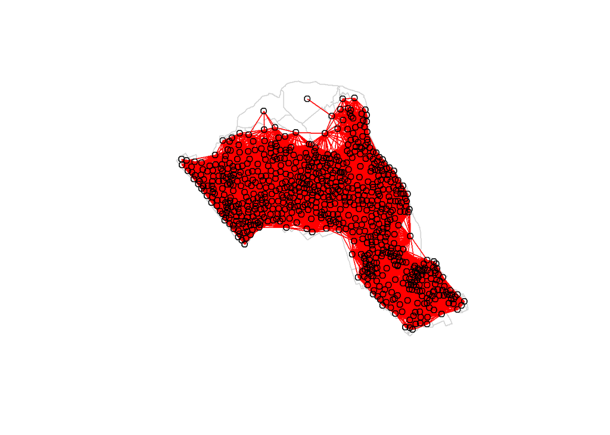

```r
plot(OA.Census, border = 'lightgrey')
plot(nb, coordinates(OA.Census), add=TRUE, col = 'red')
```

## Getis-Ord Gi statistic

NOTE: On some machines the `cbind` may not work with a spatial data file, in this case, you will need to change OA.Census to OA.Census@data so that R knows which part of the spatial data file to join. If you take this approach the subsequent column ordering may be different to what is shown in the example below.

```r
local_g <- localG(OA.Census$Qualification, nb_lw)
local_g <- cbind(OA.Census, as.matrix(local_g))
names(local_g)[6] <- "gstat"
```

## Cluster map

```r
tm_shape(local_g) +
  tm_fill("gstat",
          palette = "RdBu",
          style = "pretty") +
  tm_borders(alpha=.4)
```

```
## Variable(s) "gstat" contains positive and negative values, so midpoint is set to 0. Set midpoint = NA to show the full spectrum of the color palette.
```

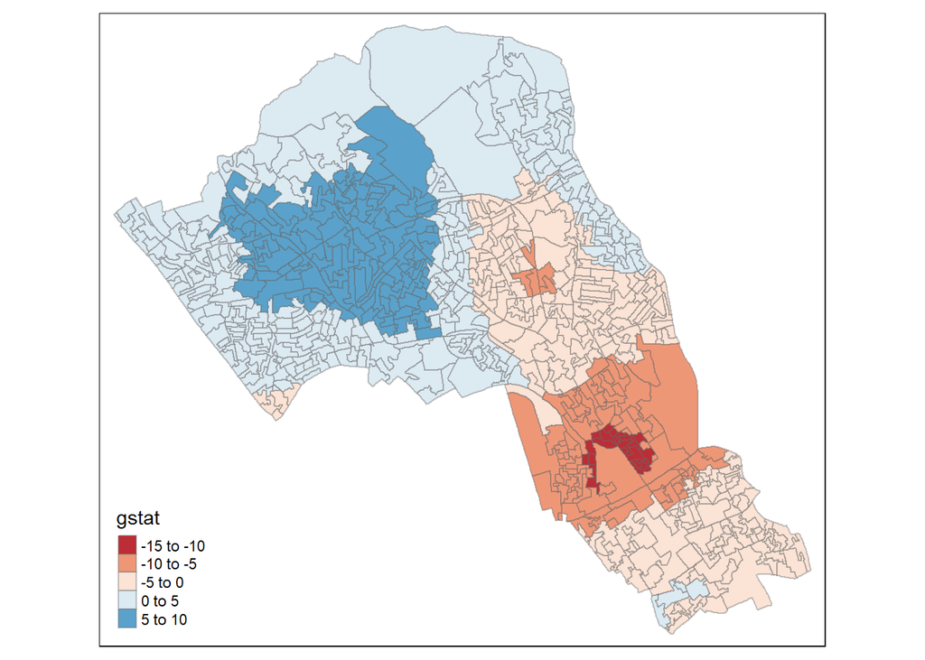

The Gi Statistic is represented as a Z-score. Greater values represent a greater intensity of clustering and the direction (positive or negative) indicates high or low clusters. The final map should indicate the location of hot-spots across Camden. Repeat this for another variable.